# Risk Factor Analysis

## Outcome Variable

**Outcome Variable:** swasted

## Predictor Variables

**Intervention Variable:** parity

**Adjustment Set:**

- arm
- W_mage
- meducyrs
- feducyrs
- hhwealth_quart
- W_mhtcm
- W_mwtkg
- W_mbmi
- vagbrth
- W_nrooms
- impsan
- delta_W_mage
- delta_meducyrs
- delta_feducyrs
- delta_hhwealth_quart
- delta_W_mhtcm
- delta_W_mwtkg
- delta_W_mbmi
- delta_vagbrth
- delta_W_nrooms
- delta_impsan

## Stratifying Variables

The analysis was stratified on these variable(s):

- agecat
- studyid
- country

## Data Summary

| agecat | studyid | country | parity | swasted | n_cell | n |
| --- | --- | --- | --- | --- | --- | --- |
| Birth | COHORTS | GUATEMALA | 1 | 0 | 84 | 756 |
| Birth | COHORTS | GUATEMALA | 1 | 1 | 10 | 756 |
| Birth | COHORTS | GUATEMALA | 2 | 0 | 109 | 756 |
| Birth | COHORTS | GUATEMALA | 2 | 1 | 9 | 756 |
| Birth | COHORTS | GUATEMALA | 3+ | 0 | 503 | 756 |
| Birth | COHORTS | GUATEMALA | 3+ | 1 | 41 | 756 |
| Birth | COHORTS | INDIA | 1 | 0 | 599 | 3855 |
| Birth | COHORTS | INDIA | 1 | 1 | 42 | 3855 |
| Birth | COHORTS | INDIA | 2 | 0 | 941 | 3855 |
| Birth | COHORTS | INDIA | 2 | 1 | 41 | 3855 |
| Birth | COHORTS | INDIA | 3+ | 0 | 2138 | 3855 |
| Birth | COHORTS | INDIA | 3+ | 1 | 94 | 3855 |
| Birth | COHORTS | PHILIPPINES | 1 | 0 | 595 | 2899 |
| Birth | COHORTS | PHILIPPINES | 1 | 1 | 45 | 2899 |
| Birth | COHORTS | PHILIPPINES | 2 | 0 | 631 | 2899 |
| Birth | COHORTS | PHILIPPINES | 2 | 1 | 26 | 2899 |
| Birth | COHORTS | PHILIPPINES | 3+ | 0 | 1552 | 2899 |
| Birth | COHORTS | PHILIPPINES | 3+ | 1 | 50 | 2899 |
| Birth | GMS-Nepal | NEPAL | 1 | 0 | 174 | 641 |
| Birth | GMS-Nepal | NEPAL | 1 | 1 | 11 | 641 |
| Birth | GMS-Nepal | NEPAL | 2 | 0 | 160 | 641 |
| Birth | GMS-Nepal | NEPAL | 2 | 1 | 9 | 641 |
| Birth | GMS-Nepal | NEPAL | 3+ | 0 | 280 | 641 |
| Birth | GMS-Nepal | NEPAL | 3+ | 1 | 7 | 641 |
| Birth | JiVitA-3 | BANGLADESH | 1 | 0 | 5387 | 18014 |
| Birth | JiVitA-3 | BANGLADESH | 1 | 1 | 133 | 18014 |
| Birth | JiVitA-3 | BANGLADESH | 2 | 0 | 6193 | 18014 |
| Birth | JiVitA-3 | BANGLADESH | 2 | 1 | 110 | 18014 |
| Birth | JiVitA-3 | BANGLADESH | 3+ | 0 | 6085 | 18014 |
| Birth | JiVitA-3 | BANGLADESH | 3+ | 1 | 106 | 18014 |

[output cut: 144 more lines]

The following strata were considered:

- agecat: 24 months, studyid: COHORTS, country: GUATEMALA
- agecat: 24 months, studyid: COHORTS, country: INDIA
- agecat: 24 months, studyid: COHORTS, country: PHILIPPINES
- agecat: 24 months, studyid: GMS-Nepal, country: NEPAL
- agecat: 24 months, studyid: JiVitA-3, country: BANGLADESH
- agecat: 24 months, studyid: Keneba, country: GAMBIA
- agecat: 24 months, studyid: PROVIDE, country: BANGLADESH
- agecat: 24 months, studyid: TanzaniaChild2, country: TANZANIA, UNITED REPUBLIC OF
- agecat: 24 months, studyid: ZVITAMBO, country: ZIMBABWE
- agecat: 6 months, studyid: COHORTS, country: GUATEMALA
- agecat: 6 months, studyid: COHORTS, country: INDIA
- agecat: 6 months, studyid: COHORTS, country: PHILIPPINES
- agecat: 6 months, studyid: GMS-Nepal, country: NEPAL
- agecat: 6 months, studyid: JiVitA-3, country: BANGLADESH
- agecat: 6 months, studyid: Keneba, country: GAMBIA
- agecat: 6 months, studyid: PROVIDE, country: BANGLADESH
- agecat: 6 months, studyid: SAS-CompFeed, country: INDIA
- agecat: 6 months, studyid: SAS-FoodSuppl, country: INDIA
- agecat: 6 months, studyid: TanzaniaChild2, country: TANZANIA, UNITED REPUBLIC OF
- agecat: 6 months, studyid: ZVITAMBO, country: ZIMBABWE
- agecat: Birth, studyid: COHORTS, country: GUATEMALA
- agecat: Birth, studyid: COHORTS, country: INDIA
- agecat: Birth, studyid: COHORTS, country: PHILIPPINES
- agecat: Birth, studyid: GMS-Nepal, country: NEPAL
- agecat: Birth, studyid: JiVitA-3, country: BANGLADESH
- agecat: Birth, studyid: Keneba, country: GAMBIA
- agecat: Birth, studyid: PROVIDE, country: BANGLADESH
- agecat: Birth, studyid: SAS-CompFeed, country: INDIA
- agecat: Birth, studyid: ZVITAMBO, country: ZIMBABWE

### Dropped Strata

Some strata were dropped due to rare outcomes:

- agecat: Birth, studyid: PROVIDE, country: BANGLADESH
- agecat: 6 months, studyid: COHORTS, country: GUATEMALA
- agecat: 6 months, studyid: COHORTS, country: PHILIPPINES
- agecat: 6 months, studyid: GMS-Nepal, country: NEPAL
- agecat: 6 months, studyid: Keneba, country: GAMBIA
- agecat: 6 months, studyid: PROVIDE, country: BANGLADESH
- agecat: 6 months, studyid: SAS-FoodSuppl, country: INDIA
- agecat: 6 months, studyid: TanzaniaChild2, country: TANZANIA, UNITED REPUBLIC OF
- agecat: 24 months, studyid: COHORTS, country: GUATEMALA
- agecat: 24 months, studyid: COHORTS, country: INDIA
- agecat: 24 months, studyid: COHORTS, country: PHILIPPINES
- agecat: 24 months, studyid: GMS-Nepal, country: NEPAL
- agecat: 24 months, studyid: Keneba, country: GAMBIA
- agecat: 24 months, studyid: PROVIDE, country: BANGLADESH
- agecat: 24 months, studyid: TanzaniaChild2, country: TANZANIA, UNITED REPUBLIC OF

## Methods Detail

We’re interested in the causal parameters $E[Y_a]$ for all values of $a \in \mathcal{A}$. These parameters represent the mean outcome if, possibly contrary to fact, we intervened to set all units to have $A=a$. Under the randomization and positivity assumptions, these are identified by the statistical parameters $\psi_a=E_W[E_{Y|A,W}(Y|A=a,W)]$. In addition, we’re interested in the mean of $Y$, $E[Y]$ under no intervention (the observed mean). We will estimate these parameters by using SuperLearner to fit the relevant likelihood factors – $E_{Y|A,W}(Y|A=a,W)$ and $p(A=a|W)$, and then updating our likelihood fit using a joint TMLE.

For unadjusted analyses ($W=\{\}$), initial likelihoods were estimated using Lrnr_glm to estimate the simple $E(Y|A)$ and Lrnr_mean to estimate $p(A)$. For adjusted analyses, a small library containing Lrnr_glmnet, Lrnr_xgboost, and Lrnr_mean was used.

Having estimated these parameters, we will then use the delta method to estimate relative risks and attributable risks relative to a prespecified baseline level of $A$.

# Results Detail

## Results Plots

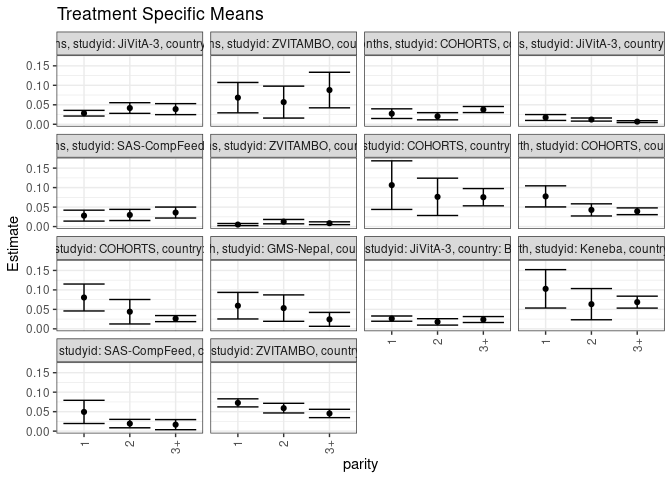

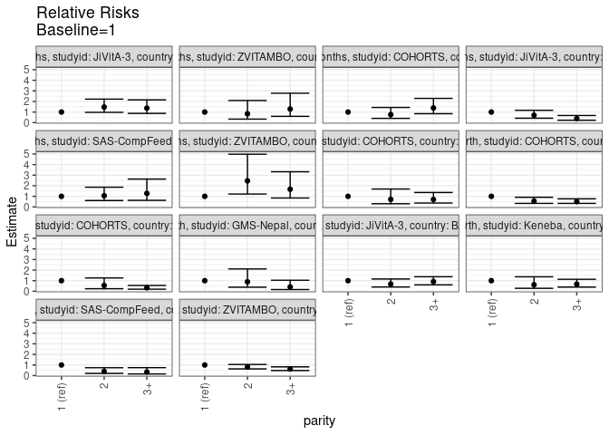

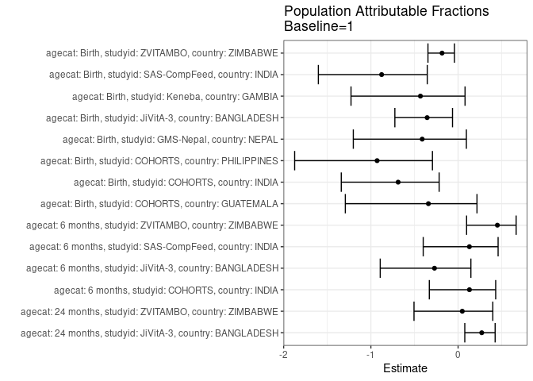

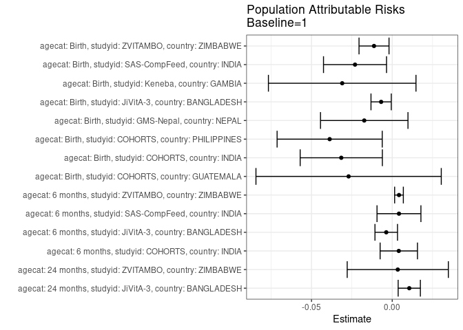

## Results Table

### Parameter: TSM

| agecat | studyid | country | intervention_level | baseline_level | estimate | ci_lower | ci_upper |
| --- | --- | --- | --- | --- | --- | --- | --- |
| Birth | COHORTS | GUATEMALA | 1 | NA | 0.1063830 | 0.0440119 | 0.1687541 |
| Birth | COHORTS | GUATEMALA | 2 | NA | 0.0762712 | 0.0283479 | 0.1241945 |
| Birth | COHORTS | GUATEMALA | 3+ | NA | 0.0753676 | 0.0531697 | 0.0975656 |
| Birth | COHORTS | INDIA | 1 | NA | 0.0774827 | 0.0504047 | 0.1045606 |
| Birth | COHORTS | INDIA | 2 | NA | 0.0427548 | 0.0271947 | 0.0583149 |
| Birth | COHORTS | INDIA | 3+ | NA | 0.0392332 | 0.0305067 | 0.0479597 |
| Birth | COHORTS | PHILIPPINES | 1 | NA | 0.0804922 | 0.0459330 | 0.1150514 |
| Birth | COHORTS | PHILIPPINES | 2 | NA | 0.0439682 | 0.0125641 | 0.0753724 |
| Birth | COHORTS | PHILIPPINES | 3+ | NA | 0.0263022 | 0.0185223 | 0.0340821 |
| Birth | GMS-Nepal | NEPAL | 1 | NA | 0.0594595 | 0.0253558 | 0.0935631 |
| Birth | GMS-Nepal | NEPAL | 2 | NA | 0.0532544 | 0.0193748 | 0.0871340 |
| Birth | GMS-Nepal | NEPAL | 3+ | NA | 0.0243902 | 0.0065298 | 0.0422507 |
| Birth | JiVitA-3 | BANGLADESH | 1 | NA | 0.0262478 | 0.0195117 | 0.0329840 |
| Birth | JiVitA-3 | BANGLADESH | 2 | NA | 0.0178587 | 0.0096089 | 0.0261085 |
| Birth | JiVitA-3 | BANGLADESH | 3+ | NA | 0.0239245 | 0.0162943 | 0.0315548 |
| Birth | Keneba | GAMBIA | 1 | NA | 0.1027397 | 0.0534720 | 0.1520074 |
| Birth | Keneba | GAMBIA | 2 | NA | 0.0633803 | 0.0232913 | 0.1034693 |
| Birth | Keneba | GAMBIA | 3+ | NA | 0.0685714 | 0.0532795 | 0.0838634 |
| Birth | SAS-CompFeed | INDIA | 1 | NA | 0.0493421 | 0.0195565 | 0.0791278 |
| Birth | SAS-CompFeed | INDIA | 2 | NA | 0.0193798 | 0.0085871 | 0.0301725 |
| Birth | SAS-CompFeed | INDIA | 3+ | NA | 0.0166359 | 0.0036649 | 0.0296069 |
| Birth | ZVITAMBO | ZIMBABWE | 1 | NA | 0.0726002 | 0.0622513 | 0.0829491 |
| Birth | ZVITAMBO | ZIMBABWE | 2 | NA | 0.0590342 | 0.0465959 | 0.0714725 |
| Birth | ZVITAMBO | ZIMBABWE | 3+ | NA | 0.0453938 | 0.0347177 | 0.0560700 |
| 6 months | COHORTS | INDIA | 1 | NA | 0.0272059 | 0.0148072 | 0.0396045 |
| 6 months | COHORTS | INDIA | 2 | NA | 0.0205921 | 0.0114080 | 0.0297762 |
| 6 months | COHORTS | INDIA | 3+ | NA | 0.0377972 | 0.0300069 | 0.0455875 |
| 6 months | JiVitA-3 | BANGLADESH | 1 | NA | 0.0174159 | 0.0098955 | 0.0249363 |
| 6 months | JiVitA-3 | BANGLADESH | 2 | NA | 0.0121008 | 0.0081240 | 0.0160777 |
| 6 months | JiVitA-3 | BANGLADESH | 3+ | NA | 0.0067805 | 0.0044536 | 0.0091075 |
| 6 months | SAS-CompFeed | INDIA | 1 | NA | 0.0280612 | 0.0140579 | 0.0420646 |
| 6 months | SAS-CompFeed | INDIA | 2 | NA | 0.0298013 | 0.0154373 | 0.0441654 |
| 6 months | SAS-CompFeed | INDIA | 3+ | NA | 0.0359375 | 0.0218263 | 0.0500487 |
| 6 months | ZVITAMBO | ZIMBABWE | 1 | NA | 0.0051060 | 0.0023395 | 0.0078724 |
| 6 months | ZVITAMBO | ZIMBABWE | 2 | NA | 0.0125915 | 0.0069515 | 0.0182316 |
| 6 months | ZVITAMBO | ZIMBABWE | 3+ | NA | 0.0085456 | 0.0049471 | 0.0121442 |
| 24 months | JiVitA-3 | BANGLADESH | 1 | NA | 0.0283820 | 0.0211276 | 0.0356365 |
| 24 months | JiVitA-3 | BANGLADESH | 2 | NA | 0.0416945 | 0.0279619 | 0.0554271 |
| 24 months | JiVitA-3 | BANGLADESH | 3+ | NA | 0.0388691 | 0.0247564 | 0.0529817 |
| 24 months | ZVITAMBO | ZIMBABWE | 1 | NA | 0.0683230 | 0.0293059 | 0.1073400 |
| 24 months | ZVITAMBO | ZIMBABWE | 2 | NA | 0.0569106 | 0.0159212 | 0.0979000 |
| 24 months | ZVITAMBO | ZIMBABWE | 3+ | NA | 0.0878378 | 0.0421819 | 0.1334938 |

### Parameter: E(Y)

| agecat | studyid | country | intervention_level | baseline_level | estimate | ci_lower | ci_upper |
| --- | --- | --- | --- | --- | --- | --- | --- |
| Birth | COHORTS | GUATEMALA | NA | NA | 0.0793651 | 0.0600839 | 0.0986462 |
| Birth | COHORTS | INDIA | NA | NA | 0.0459144 | 0.0393065 | 0.0525222 |
| Birth | COHORTS | PHILIPPINES | NA | NA | 0.0417385 | 0.0344572 | 0.0490198 |
| Birth | GMS-Nepal | NEPAL | NA | NA | 0.0421217 | 0.0265597 | 0.0576837 |
| Birth | JiVitA-3 | BANGLADESH | NA | NA | 0.0193738 | 0.0169653 | 0.0217823 |
| Birth | Keneba | GAMBIA | NA | NA | 0.0717489 | 0.0579157 | 0.0855821 |
| Birth | SAS-CompFeed | INDIA | NA | NA | 0.0262919 | 0.0122874 | 0.0402964 |
| Birth | ZVITAMBO | ZIMBABWE | NA | NA | 0.0613193 | 0.0571816 | 0.0654570 |
| 6 months | COHORTS | INDIA | NA | NA | 0.0312719 | 0.0260599 | 0.0364838 |
| 6 months | JiVitA-3 | BANGLADESH | NA | NA | 0.0137035 | 0.0116269 | 0.0157801 |
| 6 months | SAS-CompFeed | INDIA | NA | NA | 0.0322339 | 0.0235219 | 0.0409459 |
| 6 months | ZVITAMBO | ZIMBABWE | NA | NA | 0.0092897 | 0.0072507 | 0.0113288 |
| 24 months | JiVitA-3 | BANGLADESH | NA | NA | 0.0389399 | 0.0346167 | 0.0432631 |
| 24 months | ZVITAMBO | ZIMBABWE | NA | NA | 0.0717593 | 0.0473936 | 0.0961250 |

### Parameter: RR

| agecat | studyid | country | intervention_level | baseline_level | estimate | ci_lower | ci_upper |
| --- | --- | --- | --- | --- | --- | --- | --- |
| Birth | COHORTS | GUATEMALA | 1 | 1 | 1.0000000 | 1.0000000 | 1.0000000 |
| Birth | COHORTS | GUATEMALA | 2 | 1 | 0.7169492 | 0.3035745 | 1.6932122 |
| Birth | COHORTS | GUATEMALA | 3+ | 1 | 0.7084559 | 0.3675932 | 1.3653943 |
| Birth | COHORTS | INDIA | 1 | 1 | 1.0000000 | 1.0000000 | 1.0000000 |
| Birth | COHORTS | INDIA | 2 | 1 | 0.5517981 | 0.3331962 | 0.9138194 |
| Birth | COHORTS | INDIA | 3+ | 1 | 0.5063482 | 0.3347379 | 0.7659381 |
| Birth | COHORTS | PHILIPPINES | 1 | 1 | 1.0000000 | 1.0000000 | 1.0000000 |
| Birth | COHORTS | PHILIPPINES | 2 | 1 | 0.5462422 | 0.2374363 | 1.2566761 |
| Birth | COHORTS | PHILIPPINES | 3+ | 1 | 0.3267674 | 0.1940037 | 0.5503861 |
| Birth | GMS-Nepal | NEPAL | 1 | 1 | 1.0000000 | 1.0000000 | 1.0000000 |
| Birth | GMS-Nepal | NEPAL | 2 | 1 | 0.8956428 | 0.3803066 | 2.1092877 |
| Birth | GMS-Nepal | NEPAL | 3+ | 1 | 0.4101996 | 0.1618193 | 1.0398242 |
| Birth | JiVitA-3 | BANGLADESH | 1 | 1 | 1.0000000 | 1.0000000 | 1.0000000 |
| Birth | JiVitA-3 | BANGLADESH | 2 | 1 | 0.6803871 | 0.3996932 | 1.1582048 |
| Birth | JiVitA-3 | BANGLADESH | 3+ | 1 | 0.9114858 | 0.6052792 | 1.3726001 |
| Birth | Keneba | GAMBIA | 1 | 1 | 1.0000000 | 1.0000000 | 1.0000000 |
| Birth | Keneba | GAMBIA | 2 | 1 | 0.6169014 | 0.2789306 | 1.3643800 |
| Birth | Keneba | GAMBIA | 3+ | 1 | 0.6674286 | 0.3933010 | 1.1326209 |
| Birth | SAS-CompFeed | INDIA | 1 | 1 | 1.0000000 | 1.0000000 | 1.0000000 |
| Birth | SAS-CompFeed | INDIA | 2 | 1 | 0.3927649 | 0.2076508 | 0.7429023 |
| Birth | SAS-CompFeed | INDIA | 3+ | 1 | 0.3371534 | 0.1521067 | 0.7473204 |
| Birth | ZVITAMBO | ZIMBABWE | 1 | 1 | 1.0000000 | 1.0000000 | 1.0000000 |
| Birth | ZVITAMBO | ZIMBABWE | 2 | 1 | 0.8131411 | 0.6304865 | 1.0487114 |
| Birth | ZVITAMBO | ZIMBABWE | 3+ | 1 | 0.6252573 | 0.4749172 | 0.8231892 |
| 6 months | COHORTS | INDIA | 1 | 1 | 1.0000000 | 1.0000000 | 1.0000000 |
| 6 months | COHORTS | INDIA | 2 | 1 | 0.7568986 | 0.4000397 | 1.4320967 |
| 6 months | COHORTS | INDIA | 3+ | 1 | 1.3893024 | 0.8424936 | 2.2910099 |
| 6 months | JiVitA-3 | BANGLADESH | 1 | 1 | 1.0000000 | 1.0000000 | 1.0000000 |
| 6 months | JiVitA-3 | BANGLADESH | 2 | 1 | 0.6948155 | 0.4141452 | 1.1656989 |
| 6 months | JiVitA-3 | BANGLADESH | 3+ | 1 | 0.3893310 | 0.2252996 | 0.6727871 |
| 6 months | SAS-CompFeed | INDIA | 1 | 1 | 1.0000000 | 1.0000000 | 1.0000000 |
| 6 months | SAS-CompFeed | INDIA | 2 | 1 | 1.0620108 | 0.6052683 | 1.8634168 |
| 6 months | SAS-CompFeed | INDIA | 3+ | 1 | 1.2806818 | 0.6228782 | 2.6331726 |
| 6 months | ZVITAMBO | ZIMBABWE | 1 | 1 | 1.0000000 | 1.0000000 | 1.0000000 |
| 6 months | ZVITAMBO | ZIMBABWE | 2 | 1 | 2.4660478 | 1.2206972 | 4.9819002 |
| 6 months | ZVITAMBO | ZIMBABWE | 3+ | 1 | 1.6736564 | 0.8426321 | 3.3242570 |
| 24 months | JiVitA-3 | BANGLADESH | 1 | 1 | 1.0000000 | 1.0000000 | 1.0000000 |
| 24 months | JiVitA-3 | BANGLADESH | 2 | 1 | 1.4690464 | 0.9717144 | 2.2209172 |
| 24 months | JiVitA-3 | BANGLADESH | 3+ | 1 | 1.3694956 | 0.8720465 | 2.1507089 |
| 24 months | ZVITAMBO | ZIMBABWE | 1 | 1 | 1.0000000 | 1.0000000 | 1.0000000 |
| 24 months | ZVITAMBO | ZIMBABWE | 2 | 1 | 0.8329638 | 0.3322286 | 2.0884073 |
| 24 months | ZVITAMBO | ZIMBABWE | 3+ | 1 | 1.2856265 | 0.5939568 | 2.7827538 |

### Parameter: PAR

| agecat | studyid | country | intervention_level | baseline_level | estimate | ci_lower | ci_upper |
| --- | --- | --- | --- | --- | --- | --- | --- |
| Birth | COHORTS | GUATEMALA | 1 | NA | -0.0270179 | -0.0844158 | 0.0303800 |
| Birth | COHORTS | INDIA | 1 | NA | -0.0315683 | -0.0570269 | -0.0061096 |
| Birth | COHORTS | PHILIPPINES | 1 | NA | -0.0387537 | -0.0713171 | -0.0061902 |
| Birth | GMS-Nepal | NEPAL | 1 | NA | -0.0173378 | -0.0444282 | 0.0097526 |
| Birth | JiVitA-3 | BANGLADESH | 1 | NA | -0.0068740 | -0.0131586 | -0.0005894 |
| Birth | Keneba | GAMBIA | 1 | NA | -0.0309908 | -0.0766958 | 0.0147141 |
| Birth | SAS-CompFeed | INDIA | 1 | NA | -0.0230502 | -0.0425694 | -0.0035310 |
| Birth | ZVITAMBO | ZIMBABWE | 1 | NA | -0.0112809 | -0.0205697 | -0.0019922 |
| 6 months | COHORTS | INDIA | 1 | NA | 0.0040660 | -0.0075016 | 0.0156336 |
| 6 months | JiVitA-3 | BANGLADESH | 1 | NA | -0.0037124 | -0.0106946 | 0.0032699 |
| 6 months | SAS-CompFeed | INDIA | 1 | NA | 0.0041727 | -0.0094235 | 0.0177689 |
| 6 months | ZVITAMBO | ZIMBABWE | 1 | NA | 0.0041838 | 0.0014879 | 0.0068797 |
| 24 months | JiVitA-3 | BANGLADESH | 1 | NA | 0.0105579 | 0.0036825 | 0.0174332 |
| 24 months | ZVITAMBO | ZIMBABWE | 1 | NA | 0.0034363 | -0.0278897 | 0.0347623 |

### Parameter: PAF

| agecat | studyid | country | intervention_level | baseline_level | estimate | ci_lower | ci_upper |
| --- | --- | --- | --- | --- | --- | --- | --- |
| Birth | COHORTS | GUATEMALA | 1 | NA | -0.3404255 | -1.2928794 | 0.2163824 |
| Birth | COHORTS | INDIA | 1 | NA | -0.6875461 | -1.3393136 | -0.2173707 |
| Birth | COHORTS | PHILIPPINES | 1 | NA | -0.9284863 | -1.8737903 | -0.2941304 |
| Birth | GMS-Nepal | NEPAL | 1 | NA | -0.4116116 | -1.2013007 | 0.0947864 |
| Birth | JiVitA-3 | BANGLADESH | 1 | NA | -0.3548092 | -0.7249744 | -0.0640784 |
| Birth | Keneba | GAMBIA | 1 | NA | -0.4319349 | -1.2275847 | 0.0795243 |
| Birth | SAS-CompFeed | INDIA | 1 | NA | -0.8767015 | -1.6019224 | -0.3536177 |
| Birth | ZVITAMBO | ZIMBABWE | 1 | NA | -0.1839701 | -0.3454687 | -0.0418564 |
| 6 months | COHORTS | INDIA | 1 | NA | 0.1300209 | -0.3299403 | 0.4309041 |
| 6 months | JiVitA-3 | BANGLADESH | 1 | NA | -0.2709048 | -0.8927804 | 0.1466527 |
| 6 months | SAS-CompFeed | INDIA | 1 | NA | 0.1294495 | -0.4000328 | 0.4586853 |
| 6 months | ZVITAMBO | ZIMBABWE | 1 | NA | 0.4503658 | 0.0974859 | 0.6652709 |
| 24 months | JiVitA-3 | BANGLADESH | 1 | NA | 0.2711327 | 0.0767296 | 0.4246023 |
| 24 months | ZVITAMBO | ZIMBABWE | 1 | NA | 0.0478862 | -0.5055473 | 0.3978796 |